# DLL-ES IRT Analysis and Recommendations

George Kachergis

2021-04-16

## Goals

The goals are 1) to create a word list that is informative about both English and Spanish vocabulary size and 2) to ensure that there are sufficient doublets to estimate lexical overlap. On an IRT view, we can’t perfectly assess 2 (at least not without better bilingual CDI data), but we can assess criterion 1 - that is, we can look at whether the reduced word list is a good sub-test for the full CDI in each language. Our original concern was that the current DLL-ES test might not perform well for older or high ability kids due to the lack of abstract words, and we can test this formally.

The DLL lists are meant to be used together with the original English and Spanish MCDI short forms.

```
## [1] "water (beverage)"
```

```
## [1] "rain"
```

```
##  [1] "moo"         "truck"       "bottle"      "glass"       "light"
##  [6] "cloud"       "hose"        "sun"         "night night" "jump"
## [11] "look"        "sit"         "big"         "then"        "dirty"
## [16] "today"
```

Notes: the DLL lists *chicken*, whereas wordbank has both *chicken (food)* and *chicken (animal)*. Similar for *water* (beverage / not beverage both included in wordbank). We will use all related wordbank items in our analysis. There were also a lot of plurals listed on the DLL that were singular in wordbank (e.g., ears/orejas, dedos/fingers).

English DLL items not in our wordbank IRT model: *one, two, three*, *family*, *drum*, *good morning*, *also*, and *many*. Spanish DLL items not in our wordbank IRT model: *tostada*, *algunos*, *alimentar*, *sonreír*, *no hay más* (although we have *no* and *no hay*, as well as *más*), and lastimado (but we have *lastimar(se)*).

DLL2-Spanish has “esta noche” translated as “at night”, but should be “tonight”. DLL also has “puede”, a conjugation of infinitive verb *poder* (which is in Wordbank). Wordbank and DLL also often disagree about plural, e.g. *escalera*, and *pierna* on the DLL correspond to *escaleras* and *piernas* in Wordbank. (See also *brazos* and *manos.*)

## Does the DLL short form recover full form scores?

### English DLL Level 1

Using data from 3717 English-speaking children 12-18 month of age from Wordbank, we test how well sumscores from the DLL-ES1 short English form + CDI:WG short form predict children’s production scores from the full CDI (WG/WS). The left panel shows full CDI scores vs. the DLL-ES1 short + CDI:WG short score, and the right panel shows the full CDI scores vs. just the CDI:WG short form score.

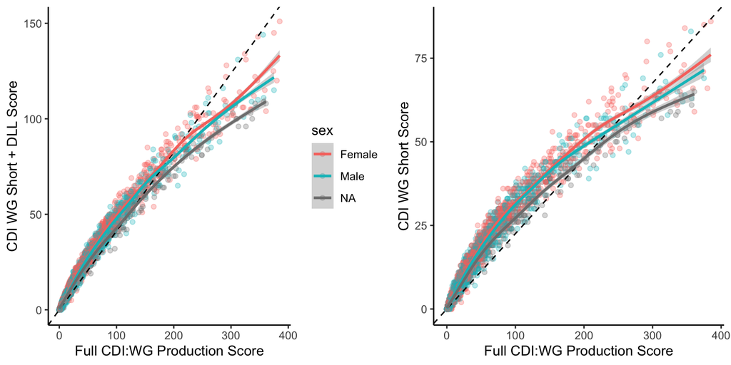

Overall, the correlation of children’s CDI:WG short + DLL scores and their full CDI production scores is quite high ($r=0.98$), but as shown above, for small vocabulary sizes the DLL score overestimates full CDI:WG production scores, while for higher full CDI:WG scores the DLL underestimates vocab size (dotted line has slope $=163 / 395$). However, the CDI:WG short form alone (right panel) shows a similar (and more extreme) overestimation for small vocabulary sizes.

### English DLL Level 2

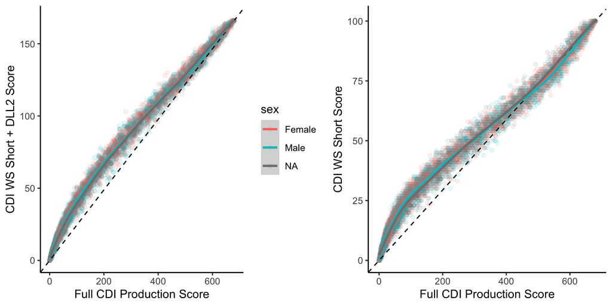

Overall, the correlation of children’s CDI:WS short + DLL2 scores and their full CDI production scores is quite high ($r=0.98$), but as shown above, the DLL2 again mostly overestimates production scores on the full CDI (dotted line has slope $=166 / 680$). In comparison, the CDI:WS short form (A) score only overestimates full CDI scores for smaller vocabulary sizes (<400).

### Spanish DLL Level 1

Now we look at overestimation for Spanish DLLs + CDI short forms.

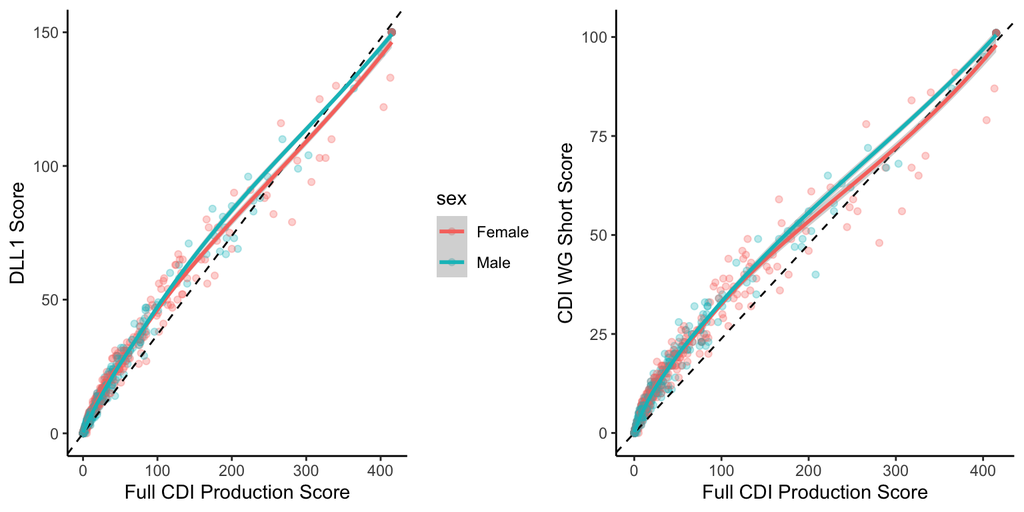

Using Wordbank data from 731 Spanish-speaking children aged 12-18 months, we test how well sumscores from the DLL-ES1 short Spanish form correlate with children’s full CDI:WG production scores.

As for English, the correlation of Spanish-speaking children’s DLL scores and their full CDI:WG production scores is quite high ($r=0.99$), but as shown above, their DLL score overestimates the production score on the full CDI at smaller vocabulary sizes (dotted line has slope $=61 / 428$). Do note that few children in this dataset have large productive vocabularies.

### Spanish DLL Level 2

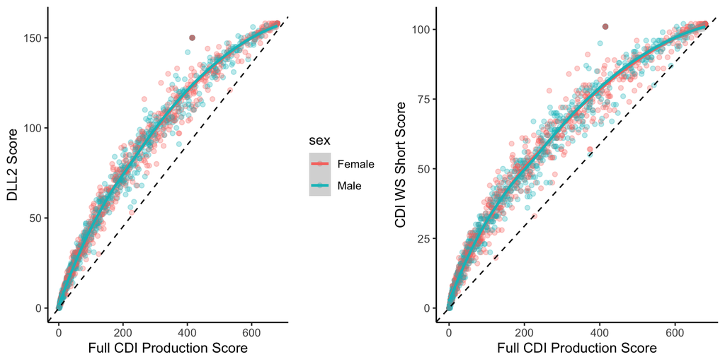

## Recommendations

Spanish DLL1 items have an average ease of -0.96, while other items on the full CDI have a mean ease of -2.02. The Spanish DLL2 shows the least bias: items on it have an average ease of -1.75, while other CDI items have a mean of -1.94.

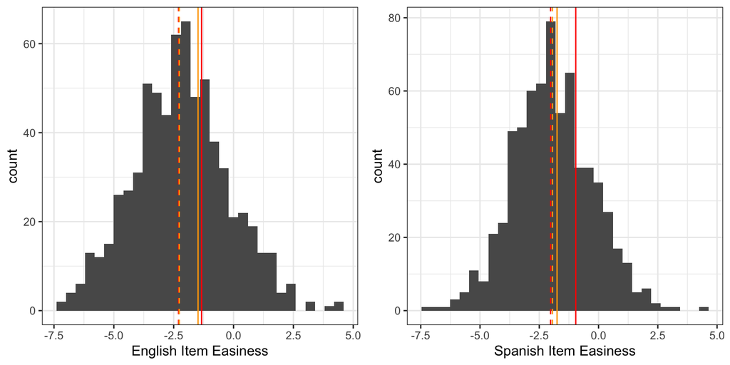

We recommend bringing the overall mean estimated IRT difficulty of the words selected for the DLLs closer to the mean difficulty of the words on the rest of the CDI.

To start, we examine IRT easiness parameters for the doublets on the existing DLL lists, looking for large itmes with large mismatch between their English and Spanish ease.

## Do doublets have similar difficulties?

We want to whether assess doublet items have similar difficulty (operationalized by their IRT parameters) in English and in Spanish. For example, consider if “perro” was for some reason much more difficult than “dog”, then you wouldn’t want to include it because it wouldn’t be a good item for estimating vocabulary overlap!

I’ve entered the English translation-equivalent item for the Spanish DLL1 items. Below are shown the parameters for these items, (en_d = English easiness, sp_d = Spanish easiness), ordered by the most to least discrepant (difficulty difference squared). (_a1 columns show item discriminations (slopes), and sp_en_d_diff simply shows Spanish - English easiness) Clearly some of these items have quite different difficulty levels, e.g. *hat* is much easier than *sombrero* (and somewhat easier than *gorra*). We may want to pick a criterion for the maximum allowable discrepancy, and try to find items that are more equivalent.

| word | translation | sp_a1 | sp_d | en_a1 | en_d | sp_en_d_diff | d_diff_sq |
| --- | --- | --- | --- | --- | --- | --- | --- |
| sombrero | hat | 3.28 | -2.14 | 3.15 | 1.37 | -3.51 | 12.33 |
| otro/otra vez | other | 2.34 | -0.84 | 3.09 | -4.05 | 3.22 | 10.34 |
| plato | dish | 4.57 | 0.17 | 2.99 | -2.90 | 3.06 | 9.39 |
| nana | babysitter | 0.97 | -1.36 | 2.41 | -4.31 | 2.94 | 8.67 |
| acabar | finish | 2.51 | -0.93 | 3.13 | -3.68 | 2.75 | 7.55 |
| mesa | table | 4.61 | 0.34 | 5.01 | -2.22 | 2.56 | 6.55 |
| afuera | outside | 3.53 | -1.82 | 2.61 | 0.44 | -2.26 | 5.10 |
| gorra | hat | 3.07 | -0.85 | 3.15 | 1.37 | -2.22 | 4.92 |
| pájaro | bird | 2.77 | -0.23 | 2.51 | 1.78 | -2.01 | 4.05 |
| niña | girl | 2.35 | 0.45 | 2.79 | -1.40 | 1.85 | 3.42 |
| nariz | nose | 4.20 | 0.45 | 3.42 | 2.18 | -1.73 | 2.99 |
| taza | cup | 3.53 | -0.84 | 3.39 | 0.83 | -1.67 | 2.79 |
| suave | soft | 3.32 | -4.34 | 3.28 | -2.74 | -1.60 | 2.55 |
| cantar | sing | 3.07 | -0.79 | 4.05 | -2.37 | 1.58 | 2.51 |
| casa | house | 4.22 | 0.55 | 3.31 | -1.03 | 1.58 | 2.49 |
| cobija | blanket | 4.49 | -1.29 | 3.26 | 0.29 | -1.57 | 2.48 |
| pato | duck | 2.50 | 0.16 | 2.27 | 1.66 | -1.50 | 2.26 |
| sofá | couch | 3.00 | -3.68 | 3.78 | -2.22 | -1.46 | 2.13 |
| dulce | candy | 3.13 | 0.63 | 2.66 | -0.75 | 1.38 | 1.91 |
| yo | I | 2.25 | 0.23 | 2.11 | -1.11 | 1.34 | 1.79 |
| ayudar | help | 4.23 | -2.32 | 3.36 | -1.07 | -1.25 | 1.55 |
| cabeza | head | 4.55 | 0.77 | 4.14 | -0.43 | 1.19 | 1.43 |
| jugo | juice | 2.88 | 0.35 | 2.42 | 1.51 | -1.16 | 1.34 |
| radio | radio | 3.89 | -1.92 | 2.83 | -3.03 | 1.11 | 1.24 |
| cereal | cereal | 2.37 | -1.67 | 3.13 | -0.57 | -1.10 | 1.21 |
| empujar | push | 3.92 | -3.13 | 3.33 | -2.03 | -1.09 | 1.20 |
| tutú | choo choo | 1.11 | -0.52 | 2.00 | 0.55 | -1.07 | 1.14 |
| casa | home | 4.22 | 0.55 | 3.34 | -0.49 | 1.04 | 1.09 |
| oscuro | dark | 3.48 | -3.75 | 3.39 | -2.76 | -1.00 | 0.99 |
| besar | kiss | 3.33 | -1.15 | 3.42 | -0.17 | -0.98 | 0.97 |
| baño | bath | 4.61 | 0.50 | 2.81 | 1.45 | -0.96 | 0.92 |
| me | me | 1.75 | -1.31 | 2.01 | -0.37 | -0.95 | 0.89 |
| piedra | rock | 4.04 | -1.49 | 3.16 | -0.55 | -0.94 | 0.89 |
| silla | chair | 4.92 | 0.91 | 4.39 | 0.11 | 0.81 | 0.65 |
| patear | kick | 3.52 | -2.69 | 3.35 | -1.93 | -0.76 | 0.57 |
| no | no | 1.50 | 1.81 | 2.09 | 2.57 | -0.76 | 0.57 |
| saltar | jump | 3.20 | -2.14 | 3.87 | -1.40 | -0.74 | 0.55 |
| noche | night | 2.95 | -2.26 | 2.59 | -1.54 | -0.73 | 0.53 |
| hola | hi | 1.94 | 1.23 | 1.45 | 1.85 | -0.62 | 0.38 |
| esperar(se) | wait | 3.60 | -3.34 | 3.02 | -2.72 | -0.61 | 0.38 |
| planta | plant | 3.89 | -2.22 | 3.12 | -2.80 | 0.58 | 0.34 |
| romper | break | 3.80 | -2.11 | 3.98 | -2.61 | 0.50 | 0.25 |
| cuchara | spoon | 4.17 | 0.04 | 3.42 | 0.54 | -0.50 | 0.25 |
| rápido (descriptive) | fast | 3.64 | -2.92 | 4.13 | -3.37 | 0.45 | 0.20 |
| brincar | jump | 3.90 | -1.02 | 3.87 | -1.40 | 0.39 | 0.15 |
| lluvia | rain | 3.60 | -1.35 | 4.29 | -0.96 | -0.38 | 0.15 |
| galleta | cookie | 2.95 | 1.21 | 2.92 | 1.56 | -0.36 | 0.13 |
| luna | moon | 3.02 | -0.19 | 2.43 | 0.09 | -0.27 | 0.08 |
| lejos | away | 2.88 | -2.79 | 2.98 | -3.05 | 0.26 | 0.07 |
| león | lion | 3.09 | -1.28 | 3.32 | -1.12 | -0.16 | 0.03 |
| lámpara | lamp | 4.22 | -3.39 | 2.94 | -3.28 | -0.11 | 0.01 |
| ratón | mouse | 3.33 | -1.10 | 3.28 | -1.13 | 0.03 | 0.00 |
| carreola | stroller | 2.41 | -1.85 | 2.61 | -1.84 | -0.01 | 0.00 |
| muñeca | doll | 2.59 | -0.30 | 2.11 | -0.30 | 0.00 | 0.00 |

### DLL Level 2

| word | translation | sp_a1 | sp_d | en_a1 | en_d | sp_en_d_diff | d_diff_sq |
| --- | --- | --- | --- | --- | --- | --- | --- |
| sombrero | hat | 3.28 | -2.14 | 3.15 | 1.37 | -3.51 | 12.33 |
| banco (outside) | bench | 2.94 | -2.18 | 3.59 | -5.43 | 3.25 | 10.57 |
| mucho | much | 3.33 | -1.80 | 3.10 | -5.04 | 3.24 | 10.48 |
| acabar | finish | 2.51 | -0.93 | 3.13 | -3.68 | 2.75 | 7.55 |
| plato | plate | 4.57 | 0.17 | 4.19 | -2.16 | 2.33 | 5.42 |
| gorra | hat | 3.07 | -0.85 | 3.15 | 1.37 | -2.22 | 4.92 |
| barco | boat | 3.41 | -2.01 | 2.90 | 0.19 | -2.20 | 4.84 |
| pájaro | bird | 2.77 | -0.23 | 2.51 | 1.78 | -2.01 | 4.05 |
| caber | fit | 3.76 | -3.43 | 4.21 | -5.30 | 1.88 | 3.52 |
| tirar | dump | 3.82 | -2.11 | 2.81 | -3.89 | 1.78 | 3.15 |
| persona | person | 3.19 | -3.76 | 3.08 | -5.51 | 1.75 | 3.05 |
| abajo | down | 3.46 | -1.17 | 2.22 | 0.46 | -1.63 | 2.66 |
| feliz | happy | 3.08 | -3.12 | 2.86 | -1.53 | -1.59 | 2.52 |
| columpio | swing (object) | 3.80 | -1.96 | 3.21 | -0.49 | -1.47 | 2.16 |
| dulce | candy | 3.13 | 0.63 | 2.66 | -0.75 | 1.38 | 1.91 |
| nosotros | us | 3.51 | -4.73 | 3.31 | -6.09 | 1.36 | 1.86 |
| amiga | friend | 2.84 | -1.99 | 3.50 | -3.35 | 1.36 | 1.85 |
| después | after | 2.93 | -4.03 | 3.88 | -5.37 | 1.34 | 1.78 |
| día | day | 2.70 | -2.47 | 3.09 | -3.76 | 1.29 | 1.66 |
| basura | trash | 4.54 | -0.03 | 2.20 | -1.28 | 1.25 | 1.56 |
| escuchar | listen | 2.97 | -2.99 | 3.70 | -4.23 | 1.24 | 1.54 |
| una | a | 2.32 | -1.10 | 2.25 | -2.33 | 1.23 | 1.52 |
| peine | comb | 3.94 | -0.68 | 2.92 | -1.90 | 1.23 | 1.50 |
| perro | dog | 1.83 | 1.28 | 1.93 | 2.49 | -1.21 | 1.47 |
| bee/mee | baa baa | 0.83 | -0.30 | 1.17 | 0.90 | -1.20 | 1.45 |
| jugo | juice | 2.88 | 0.35 | 2.42 | 1.51 | -1.16 | 1.34 |
| gustar | like | 4.32 | -2.70 | 4.56 | -3.76 | 1.06 | 1.12 |
| estrella | star | 3.85 | -1.78 | 2.82 | -0.76 | -1.01 | 1.03 |
| oso | bear | 2.96 | -0.09 | 2.48 | 0.81 | -0.91 | 0.83 |
| ellos | them | 3.42 | -4.51 | 3.26 | -5.40 | 0.89 | 0.80 |
| hola | hello | 1.94 | 1.23 | 1.41 | 0.35 | 0.87 | 0.76 |
| horno | oven | 3.65 | -4.32 | 3.69 | -3.51 | -0.81 | 0.66 |
| noche | night | 2.95 | -2.26 | 2.59 | -1.54 | -0.73 | 0.53 |
| miau | meow | 1.54 | 0.91 | 2.01 | 1.61 | -0.70 | 0.49 |
| collar | necklace | 3.37 | -2.99 | 3.02 | -2.29 | -0.70 | 0.49 |
| terminar | finish | 3.35 | -3.05 | 3.13 | -3.68 | 0.63 | 0.40 |
| hola | hi | 1.94 | 1.23 | 1.45 | 1.85 | -0.62 | 0.38 |
| frío | cold | 3.63 | -0.72 | 3.45 | -0.11 | -0.60 | 0.37 |
| un | a | 2.42 | -1.81 | 2.25 | -2.33 | 0.52 | 0.27 |
| toalla | towel | 4.89 | -2.02 | 4.12 | -1.51 | -0.52 | 0.27 |
| escuela | school | 3.56 | -0.88 | 2.87 | -1.39 | 0.51 | 0.27 |
| rápido (descriptive) | fast | 3.64 | -2.92 | 4.13 | -3.37 | 0.45 | 0.20 |
| lluvia | rain | 3.60 | -1.35 | 4.29 | -0.96 | -0.38 | 0.15 |
| caballo | horse | 2.99 | 0.65 | 3.34 | 0.32 | 0.34 | 0.11 |
| último | last | 4.55 | -6.41 | 4.06 | -6.69 | 0.28 | 0.08 |
| escaleras | stairs | 4.20 | -1.84 | 3.28 | -2.12 | 0.28 | 0.08 |
| llevar(se) | carry | 4.34 | -3.36 | 4.09 | -3.10 | -0.26 | 0.07 |
| avión | airplane | 2.81 | 0.24 | 2.97 | 0.48 | -0.24 | 0.06 |
| pensar | think | 3.96 | -5.63 | 3.87 | -5.86 | 0.22 | 0.05 |
| cielo | sky | 3.87 | -1.37 | 2.88 | -1.59 | 0.22 | 0.05 |
| bandera | flag | 3.48 | -2.62 | 2.71 | -2.42 | -0.21 | 0.04 |
| gracias | thank you | 2.27 | 1.35 | 2.04 | 1.17 | 0.18 | 0.03 |
| recámara | bedroom | 3.72 | -3.19 | 4.14 | -3.03 | -0.17 | 0.03 |
| calcetín | sock | 3.26 | 0.16 | 2.01 | 0.23 | -0.07 | 0.01 |
| piernas | leg | 4.49 | -1.64 | 4.86 | -1.69 | 0.05 | 0.00 |

## Recommended Item Swaps

We will use Wordbank’s unilemmas to find translation-equivalent pairs that have smaller d_diff_sq values than current DLL items. We first get the English / Spanish unilemmas from wordbank (both WS and WG), and below simply show the Spanish vs. English easiness parameters.

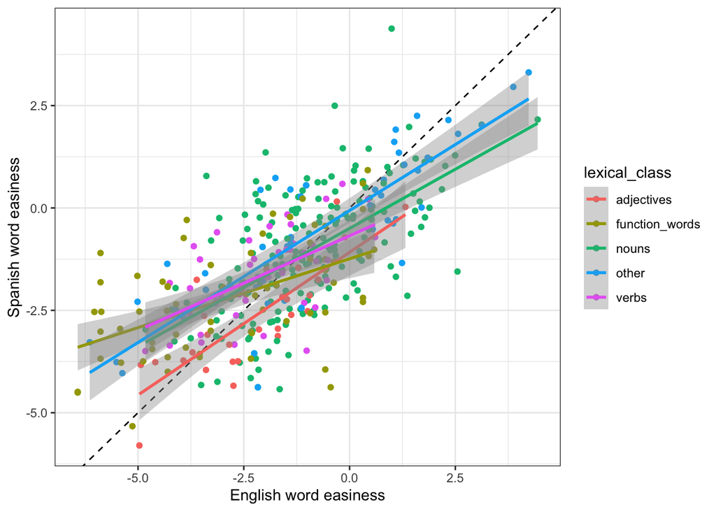

Working with 381 unilemmas that match both our English and Spanish IRT parameters. For each DLL list we will simply swap the N=15 items with the largest easiness difference for items with minimal easiness difference. We also attempt to find replacement items of the same lexical class. We report the original DLL list’s easiness SSE, as well as the improvement in (easiness SSE) after each swap is made.

## English Level 1 DLL

```r
new_dll1ENshort <- improve_DLL_list(dll1ENshort, dict, Nswaps=Nswaps, language="english")$new_list
```

```
## [1] "Original list item easiness SSE: 150.24"
## [1] "Mean Spanish item easiness: -0.8"
## [1] "Mean English item easiness: -1.34"
## [1] "Selecting from 291 words on both Eng/Sp CDIs that are not on the DLL."
## [1] "Replacing 'water (beverage)' with 'doll' (SSE improvement = 11.46)"
## [1] "Replacing 'none' with 'these' (SSE improvement = 12.63)"
## [1] "Replacing 'on' with 'all' (SSE improvement = 15.45)"
## [1] "Replacing 'her' with 'that' (SSE improvement = 11.25)"
## [1] "Replacing 'street' with 'stroller' (SSE improvement = 17.35)"
## [1] "Replacing 'meat' with 'mouse' (SSE improvement = 4.52)"
## [1] "Replacing 'glass' with 'toy (object)' (SSE improvement = 5.32)"
## [1] "Replacing 'truck' with 'sock' (SSE improvement = 5.75)"
## [1] "Replacing 'bathroom' with 'stove' (SSE improvement = 5.82)"
## [1] "Replacing 'there' with 'same' (SSE improvement = 2.75)"
## [1] "Replacing 'chicken (food)' with 'leg' (SSE improvement = 2.99)"
## [1] "Replacing 'his' with 'why' (SSE improvement = 5.98)"
## [1] "Replacing 'sun' with 'diaper' (SSE improvement = 1.69)"
## [1] "Replacing 'sleep' with 'blow' (SSE improvement = 1.71)"
## [1] "Replacing 'hot' with 'full' (SSE improvement = 1.64)"
## [1] "New list item easiness SSE: 43.93"
## [1] "Mean Spanish item easiness: -1.09"
## [1] "Mean English item easiness: -1.33"
```

```r
write.csv(new_dll1ENshort, file="DLL/new_DLL-ES1-short-English.csv")
```

## English Level 2 DLL

```r
new_dll2ENshort <- improve_DLL_list(dll2ENshort, dict, Nswaps=Nswaps, language="english")$new_list
```

```
## [1] "Original list item easiness SSE: 106.84"
## [1] "Mean Spanish item easiness: -1.02"
## [1] "Mean English item easiness: -1.14"
## [1] "Selecting from 319 words on both Eng/Sp CDIs that are not on the DLL."
## [1] "Replacing 'street' with 'doll' (SSE improvement = 17.35)"
## [1] "Replacing 'glass' with 'stroller' (SSE improvement = 5.33)"
## [1] "Replacing 'truck' with 'sink' (SSE improvement = 5.76)"
## [1] "Replacing 'bathroom' with 'mouse' (SSE improvement = 5.82)"
## [1] "Replacing 'his' with 'where (question)' (SSE improvement = 6.1)"
## [1] "Replacing 'good night' with 'wanna' (SSE improvement = 6.64)"
## [1] "Replacing 'today' with 'shh' (SSE improvement = 7.38)"
## [1] "Replacing 'boy' with 'yum yum' (SSE improvement = 2.05)"
## [1] "Replacing 'fall' with 'blow' (SSE improvement = 2.08)"
## [1] "Replacing 'broken' with 'full' (SSE improvement = 2.01)"
## [1] "Replacing 'out' with 'these' (SSE improvement = 2.1)"
## [1] "Replacing 'belly button' with 'toy (object)' (SSE improvement = 2.11)"
## [1] "Replacing 'big' with 'sick' (SSE improvement = 2.3)"
## [1] "Replacing 'soap' with 'stove' (SSE improvement = 2.35)"
## [1] "Replacing 'moo' with 'baby' (SSE improvement = 2.82)"
## [1] "New list item easiness SSE: 34.65"
## [1] "Mean Spanish item easiness: -1.14"
## [1] "Mean English item easiness: -1.15"
```

```r
write.csv(new_dll2ENshort, file="DLL/new_DLL-ES2-short-English.csv")
```

## Spanish Level 1 DLL

```r
new_dll1SPshort <- improve_DLL_list(dll1SPshort %>% select(-translation), dict, Nswaps=Nswaps, language="spanish")$new_list
```

```
## [1] "Original list item easiness SSE: 114.15"
## [1] "Mean Spanish item easiness: -0.78"
## [1] "Mean English item easiness: -0.74"
## [1] "Selecting from 328 words on both Eng/Sp CDIs that are not on the DLL."
## [1] "Replacing 'finish' with 'blow' (SSE improvement = 7.55)"
## [1] "Replacing 'babysitter' with 'cockadoodledoo' (SSE improvement = 8.66)"
## [1] "Replacing 'water (beverage)' with 'sink' (SSE improvement = 11.46)"
## [1] "Replacing 'good night' with 'wanna' (SSE improvement = 6.64)"
## [1] "Replacing 'hat' with 'toy (object)' (SSE improvement = 12.33)"
## [1] "Replacing 'bird' with 'stove' (SSE improvement = 4.05)"
## [1] "Replacing 'plate' with 'train' (SSE improvement = 5.42)"
## [1] "Replacing 'bathroom' with 'diaper' (SSE improvement = 5.81)"
## [1] "Replacing 'girl' with 'shh' (SSE improvement = 3.39)"
## [1] "Replacing 'table' with 'hair' (SSE improvement = 6.54)"
## [1] "Replacing 'out' with 'where (question)' (SSE improvement = 2.1)"
## [1] "Replacing 'couch' with 'watch (object)' (SSE improvement = 2.12)"
## [1] "Replacing 'duck' with 'grapes' (SSE improvement = 2.24)"
## [1] "Replacing 'blanket' with 'sweater' (SSE improvement = 2.47)"
## [1] "Replacing 'candy' with 'bedroom' (SSE improvement = 1.88)"
## [1] "New list item easiness SSE: 31.49"
## [1] "Mean Spanish item easiness: -1"
## [1] "Mean English item easiness: -0.83"
```

```r
write.csv(new_dll1SPshort, file="DLL/new_DLL-ES1-short-Spanish.csv")
```

## Spanish Level 2 DLL

```r
new_dll2SPshort <- improve_DLL_list(dll2SPshort %>% select(-translation), dict, Nswaps=Nswaps, language="spanish")$new_list
```

```
## [1] "Original list item easiness SSE: 73.77"
## [1] "Mean Spanish item easiness: -1.27"
## [1] "Mean English item easiness: -1.28"
## [1] "Selecting from 330 words on both Eng/Sp CDIs that are not on the DLL."
## [1] "Replacing 'finish' with 'blow' (SSE improvement = 7.55)"
## [1] "Replacing 'hat' with 'doll' (SSE improvement = 12.33)"
## [1] "Replacing 'bird' with 'stroller' (SSE improvement = 4.05)"
## [1] "Replacing 'boat' with 'sink' (SSE improvement = 4.84)"
## [1] "Replacing 'plate' with 'mouse' (SSE improvement = 5.42)"
## [1] "Replacing 'a lot' with 'where (question)' (SSE improvement = 6.85)"
## [1] "Replacing 'swing (object)' with 'toy (object)' (SSE improvement = 2.15)"
## [1] "Replacing 'candy' with 'stove' (SSE improvement = 1.9)"
## [1] "Replacing 'down' with 'these' (SSE improvement = 2.66)"
## [1] "Replacing 'person' with 'cockadoodledoo' (SSE improvement = 3.04)"
## [1] "Replacing 'after' with 'shh' (SSE improvement = 1.76)"
## [1] "Replacing 'they' with 'all' (SSE improvement = 3.67)"
## [1] "Replacing 'juice' with 'train' (SSE improvement = 1.33)"
## [1] "Replacing 'baa baa' with 'yum yum' (SSE improvement = 1.44)"
## [1] "Replacing 'dog' with 'diaper' (SSE improvement = 1.46)"
## [1] "New list item easiness SSE: 13.32"
## [1] "Mean Spanish item easiness: -1.2"
## [1] "Mean English item easiness: -1.22"
```

```r
write.csv(new_dll2SPshort, file="DLL/new_DLL-ES2-short-Spanish.csv")
```

## Overestimation in new DLL lists

The new DLL1 English short form (left) certainly looks like it’s overestimating less (compare to just the CDI:WG short form). We quantify the reliability (ICC1) and the overall root mean squared error (RMSE) of the new DLL form + CDI short form, just the CDI short form, and of the old DLL form.

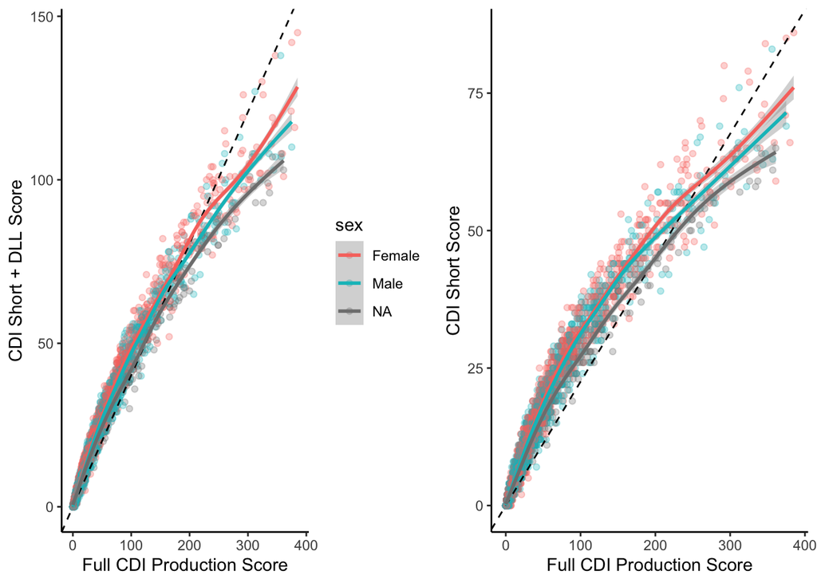

| DLL | DLL.vs..full.ICC1 | CDI.short.vs..full.ICC1 | DLL.vs..full.RMSE | CDI.short.vs..full.RMSE |
| --- | --- | --- | --- | --- |
| Old DLL1 EN short | 0.97 | 0.92 | 10.93 | 19.97 |
| New DLL1 EN short | 0.97 | 0.92 | 11.42 | 19.97 |
| Old DLL2 EN short | 0.97 | 0.96 | 43.45 | 46.30 |
| New DLL2 EN short | 0.97 | 0.96 | 42.22 | 46.30 |
| Old DLL1 SP short | 0.98 | 0.97 | 12.22 | 18.67 |
| New DLL1 SP short | 0.98 | 0.97 | 11.81 | 18.67 |
| Old DLL2 SP short | 0.96 | 0.94 | 48.27 | 62.35 |
| New DLL2 SP short | 0.96 | 0.94 | 49.65 | 62.35 |